# TAREA 2: Predicción con Series Temporales

Rubén Giménez Martín

19 de abril de 2019

# Introducción y objetivos del ejercicio

En el siguiente ejercicio se tratará de, tras un breve análisis, predecir los valores para 2018 de la serie proporcionada en las instrucciones del ejercicio (sobre la serie original y la serie transformada).

### Breve descripción de la serie temporal proporcionada

La serie temporal proporcionada en las instrucciones del ejercicio se caracteriza por tratarse de datos relacionados con la ocupación de apartamentos turísticos. Se desconoce las características específicas de los datos proporcionados. De la misma manera, dado que las especificaciones proporcionadas en las instrucciones no aportan más información, no se puede determinar inicialmente si se tratan de datos pertenecientes exclusivamente a la Comunidad Valenciana o a todo el Estado Español.

Por otro lado, la serie se caracteriza por proporcionar datos medidos mensualmente, es decir, para cada año comprendido en la serie se obtienen 12 registros (ciclo mensual de 12 registros).

Esta serie temporal viene acompañada de diferentes regresores mensuales, tanto de la Comunidad Valenciana como de el Estado Español. Estos regresores serán utilizados posteriormente en la fase de predicción.

Descripción inicial proporcionada:

- Ocupación
- Apartamentos Turísticos
- PAT

# Análisis de la Serie Temporal

### Análisis General

El siguiente gráfico muestra la serie temporal proporcionada. En un primer vistazo, se pueden observar grandes picos a lo largo de todos los años. Mostrando una muy marcada estacionalidad, suceso que no es descabellado, dado que la ocupación turística es un fenómeno altamente estacional con picos muy altos en meses de verano y bajones significativos en los meses de invierno.

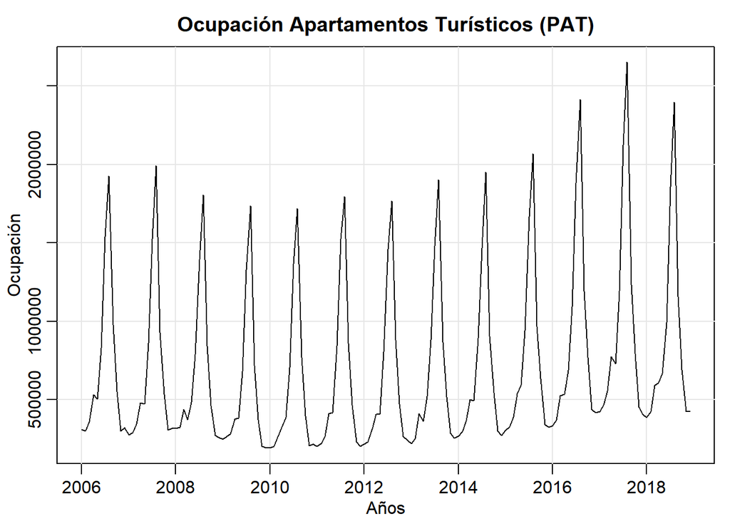

Se observa a continuación un resumen de los principales estadísticos de la serie.

```
##       date                         values
##  Min.   :2006-01-01 00:00:00   Min.   : 190710
##  1st Qu.:2009-04-01 00:00:00   1st Qu.: 320855
##  Median :2012-07-01 00:00:00   Median : 472758
##  Mean   :2012-07-01 07:11:04   Mean   : 711379
##  3rd Qu.:2015-10-01 00:00:00   3rd Qu.: 880126
##  Max.   :2019-01-01 00:00:00   Max.   :2651025
```

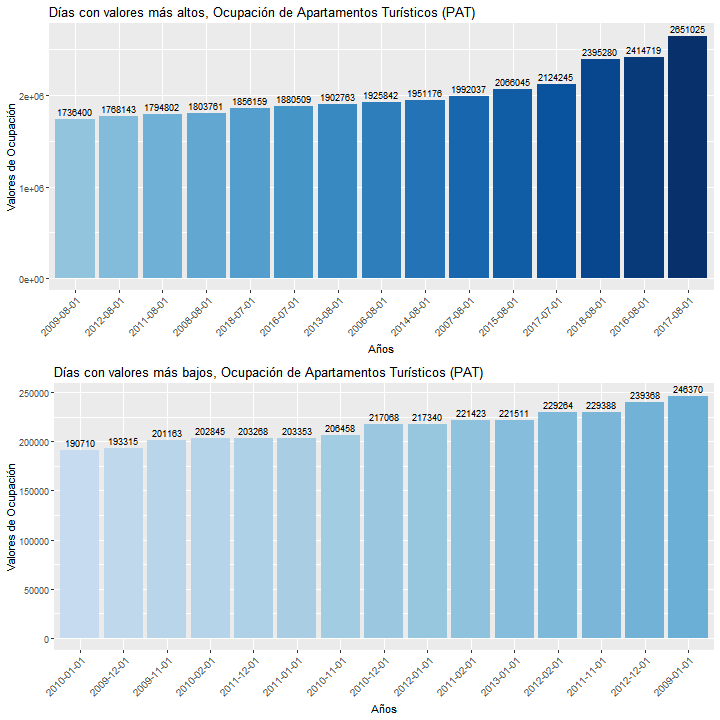

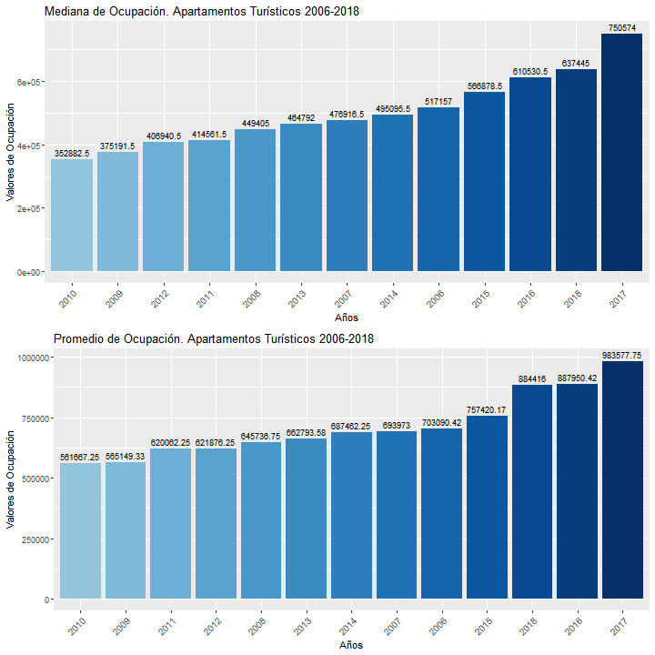

### Descomposición y análisis de los componentes de la serie.

A continuación, se procede a una descomposición clásica de la serie temporal original acompañada de otra descomposición más robusta a través del método STL (“Seasonal and Trend decomposition using Loess”).

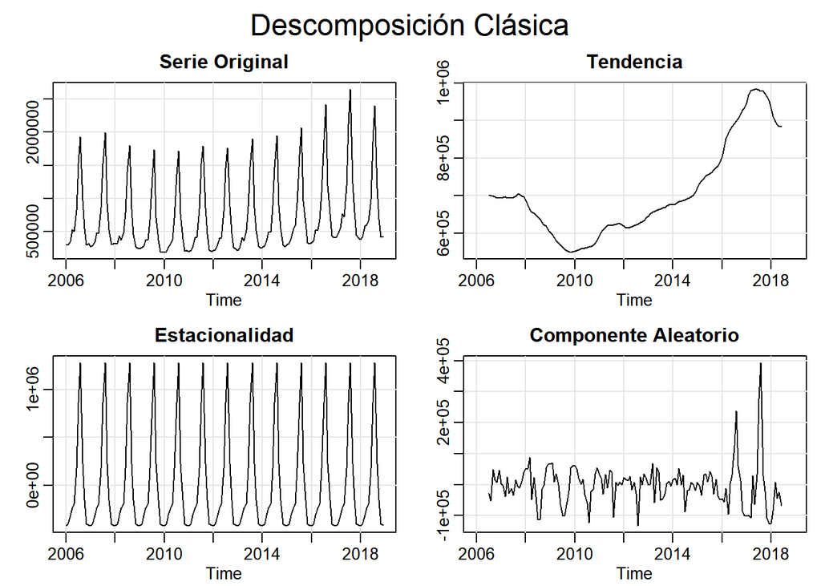

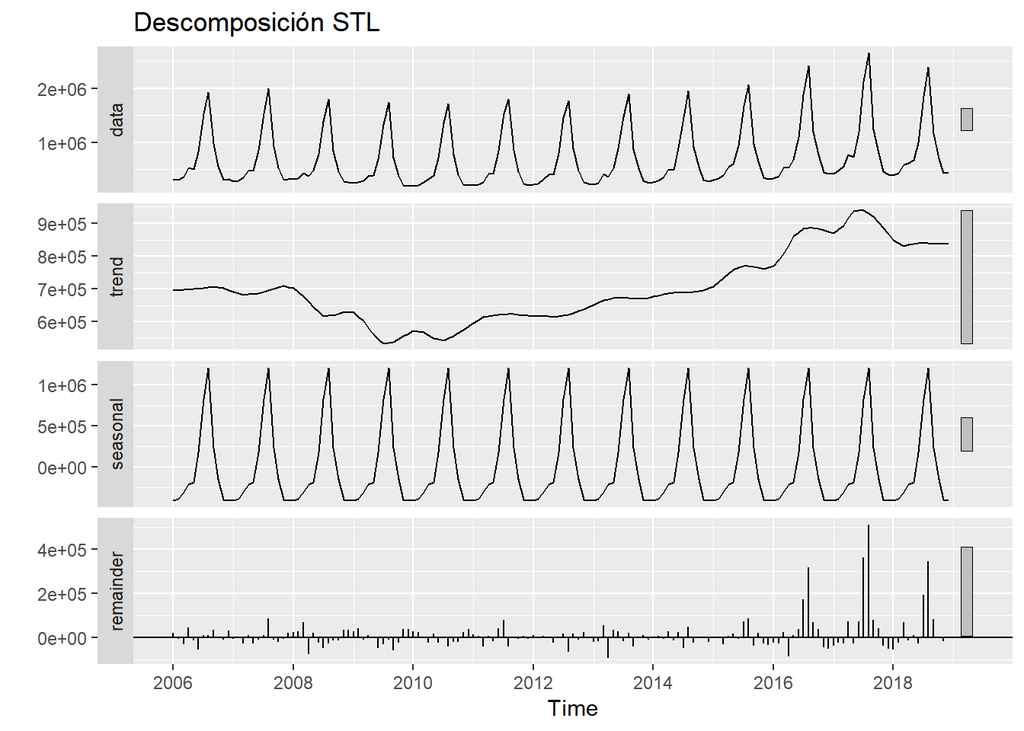

En ambos conjuntos de gráficos se pueden observar prácticamente los mismos comportamientos tanto para la tendencia y la estacionalidad, como para el componente aleatorio

Las características principales son:

- Estacionalidad anual muy marcada y constante.
- Tendencia general no constante, decreciente en los años inmediatamente posteriores a la crisis, sucedida de una tendencia con pendiente ascendente hasta aproximadamente mediados de 2017, donde hay un claro descenso de nuevo.
- Los residuos muestran una significativa desestabilidad en su variabilidad a partir del año 2016.

**Estudio de la tendencia**

Para observar de una mejor manera el comportamiento general del componente tendencia se ha realizado una representación gráfica de la aplicación del método de medias móviles. Se ha estimado el gráfico de k=25 como el óptimo para analizar la tendencia.

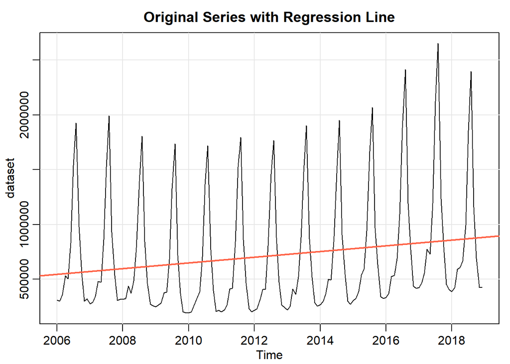

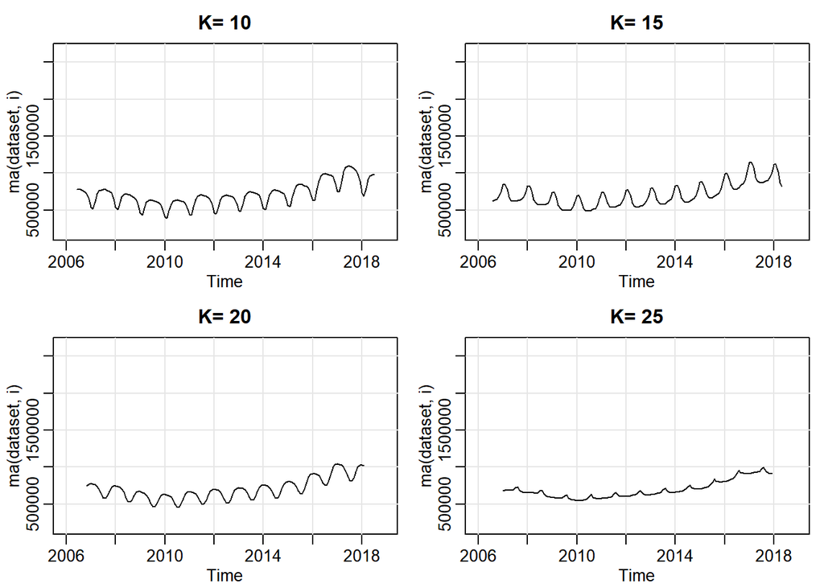

Como se puede comprobar, en general, todos los gráficos de las representaciones de medias móviles se ven significativamente afectados por el fuerte componente estacional. La recta de regresión representada en el primero de los gráficos muestra que, en su cómputo general, la serie muestra una ligera pero significativa pendiente ascendente.

**Estudio de la estacionalidad**

En el siguiente gráfico enfatiza los patrones estacionales de la serie.En él, las lineas horizontales azules muestran la media para cada es. Por otro lado, muestra claramente como para todos los años, los valores más altos se encuentran claramente en los meses estivales, lo que no hace más que confirmar, la clara y constante estacionalidad de la serie analizada.

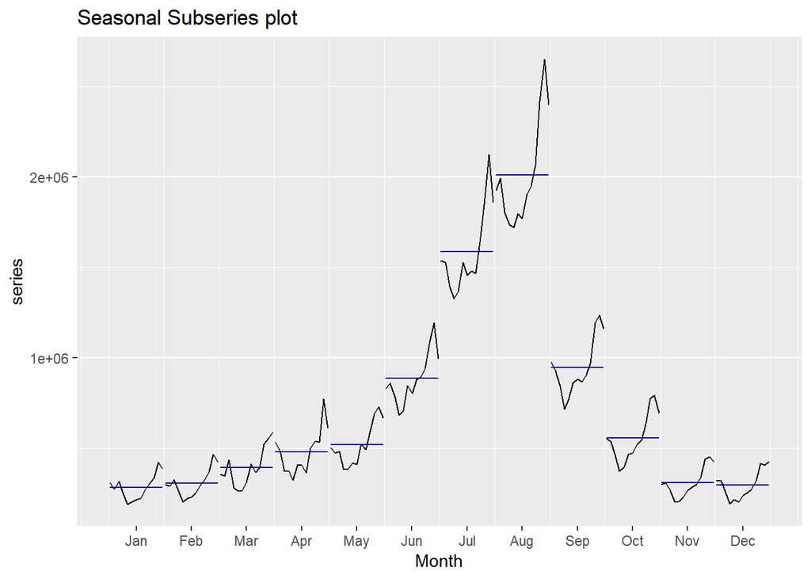

**Estudio del componente aleatorio**

En cuanto al componente aleatorio, si se observa su gráfico de autocorrelación (gráfico inferior), se observa que se ve fuertemente afectado por la fuerte estacionalidad de la serie , por lo tanto, se puede determinar que existe una fuerte autocorrelación de memoria larga de los componentes aleatorios a lo largo de la serie temporal.

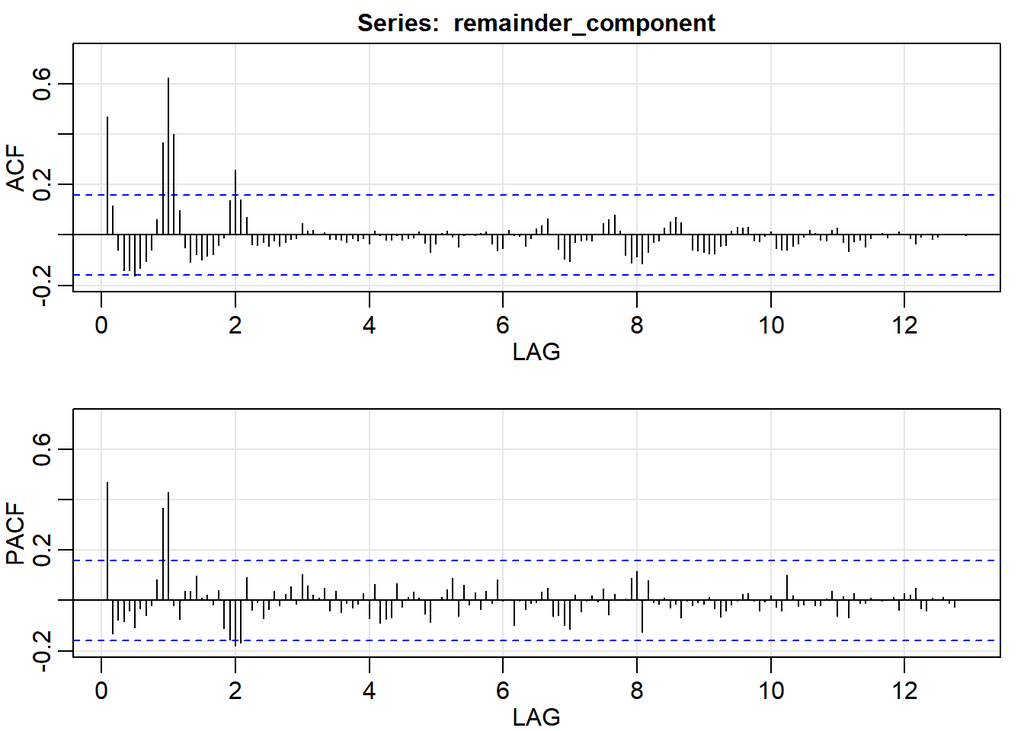

**Conclusiones de la descomposición**

Como bien se podía intuir en el gráfico general, esta serie temporal está fuertemente afectada por un componente estacional muy marcado. En cómputo general, la serie no muestra una tendencia constante visible, sin embargo si que, aparentemente, cuenta con una ligera pendiente ascendente. Por lo tanto se puede determinar que todos los gráficos mostrados anteriormente apuntan a que la tendencia de esta serie temporal sigue un esquema multiplicativo.

Se comprueba a continuación la siguiente información mediante el método de las diferencias y cocientes estacionales, el cual consiste en:

- Se calculan las diferencias absolutas $X_{t+1}-X_t$ y las diferencias relativas $X{t+1}/X_t$.
- Se calculan los cocientes de variación $CV = \frac{std}{\bar{x}}$ para las diferencias y los cocientes.
- Si $CV(X_{t+1}-X_t)<CV(X{t+1}/X_t) \longrightarrow$Esquema aditivo
- Si $CV(X_{t+1}-X_t)>CV(X{t+1}/X_t)\longrightarrow$Equema Multiplicativo

```r
schema_checker(series)
```

```
## [1] "multiplicative"
```

Se concluye que la tendencia sigue un esquema multiplicativo y que, dado que la media y la variabilidad de los datos de la serie no se mantienen constantes a lo largo del tiempo, se trata de una serie **no estacionaria**.

### Transformaciones matemáticas

En este apartado, se tratará de aislar la componente aleatoria con el objetivo de, en futuros apartados del ejercicio, conocer el comportamiento de la serie temporal a largo plazo. Este aislamiento se llevará acabo siguiendo el enfoque de Box-Jenkins, es decir, eliminando la tendencia y la parte estacional mediante transformaciones o filtros.

Las transformaciones matemáticas que se llevarán a cabo serán las siguientes:

- Ajuste para corregir el efecto calendario calendario
- Transformación Box-Cox para estabilizar la variabilidad de los datos.
- Método de la diferencia para tratar de eliminar el componente tendencia.

Se observan a continuación una serie de gráficos que muestran la evolución de la serie original después de cada transformación.

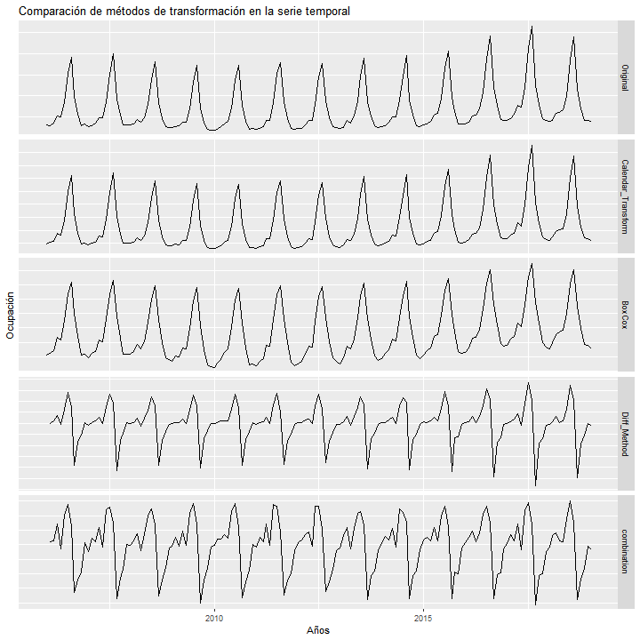

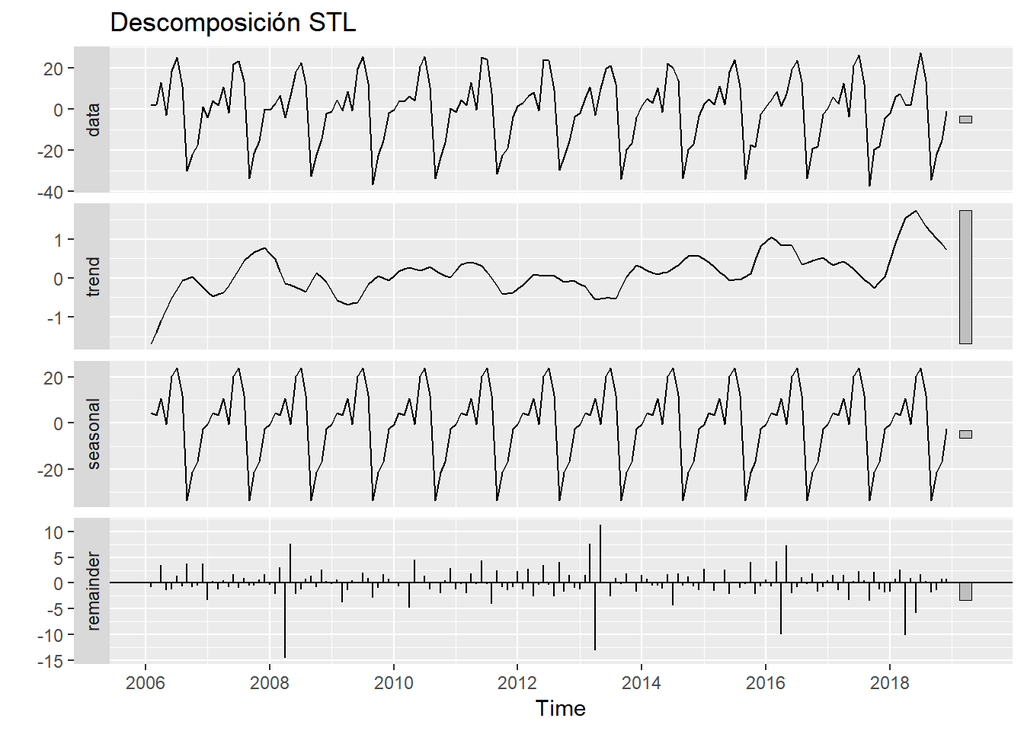

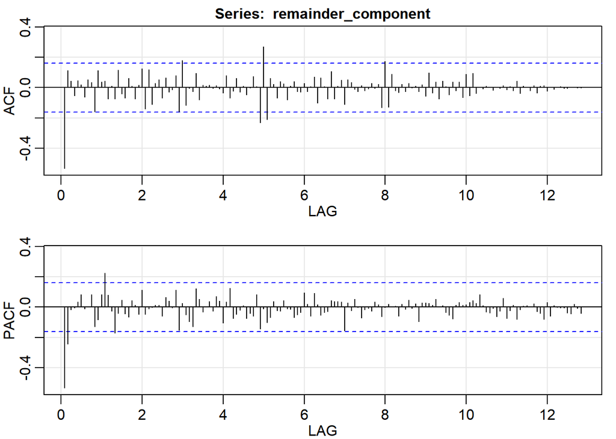

# Predicción

Una vez llevadas a cabo las transformaciones requeridas, en este apartado se procederá a implementar diversos métodos para tratar de elaborar la mejor predicción posible para los datos de la serie en el año 2018.

Los métodos utilizados serán los siguientes:

- Métodos simples
- Métodos de regresión de series temporales
- Métodos de alisado exponencial
- Modelos ARIMA

### Métodos simples

Los métodos simples implementados en este apartado, tanto para la serie original como para la transformada serán los siguientes:

```r
### Original Series ####
# Average Method
mean_fit <- meanf(train, h = 12)
# Naive Method
naive_fit <- naive(train, h = 12)
# Seasonal Naive Method
snaive_fit <- snaive(train, h = 12)
# Drift Method
drift_fit <- rwf(train, h = 12, drift=TRUE)

### Transformed Series ###
# Average Method
tr_mean_fit <- meanf(tr_train, h = 12)
# Naive Method
tr_naive_fit <- naive(tr_train, h = 12)
# Seasonal Naive Method
tr_snaive_fit <- snaive(tr_train, h = 12)
# Drift Method
tr_drift_fit <- rwf(tr_train, h = 12, drift=TRUE)
```

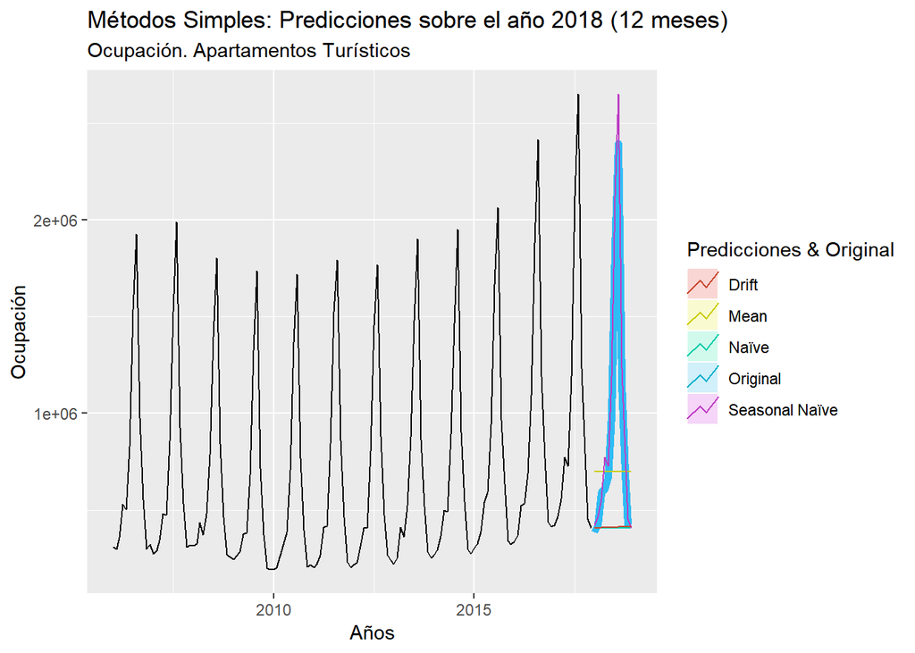

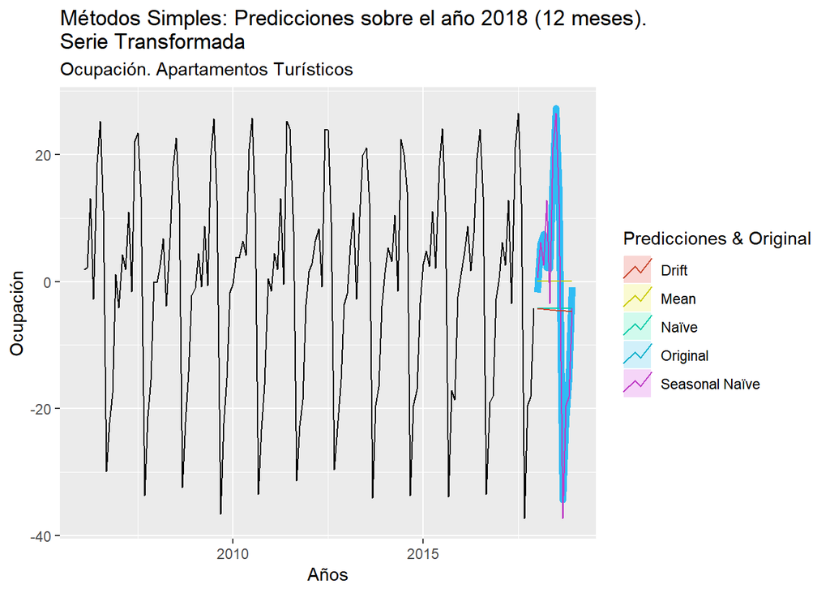

```
##            Set     Method      RMSE       MAE      ACF1
## 1 Training Set   mean_fit 546885.17 428374.06 0.6964180
## 2     Test Set   mean_fit 636321.12 415518.48 0.6112936
## 3 Training Set  naive_fit 425673.39 289573.57 0.2885347
## 4     Test Set  naive_fit 773521.37 480954.83 0.6112936
## 5 Training Set snaive_fit  86769.72  63203.95 0.6214249
## 6     Test Set snaive_fit 138562.69 107462.08 0.3900091
## 7 Training Set  drift_fit 425672.83 289443.04 0.2885347
## 8     Test Set  drift_fit 770388.86 476576.68 0.6107340
```

```
##            Set        Method      RMSE       MAE        ACF1
## 1 Training Set   tr_mean_fit 16.288020 12.742094  0.48015694
## 2     Test Set   tr_mean_fit 16.305909 12.399598  0.48040195
## 3 Training Set  tr_naive_fit 16.661856 11.896545 -0.05383123
## 4     Test Set  tr_naive_fit 16.872574 14.097593  0.48040195
## 5 Training Set tr_snaive_fit  4.180423  2.877596 -0.66662513
## 6     Test Set tr_snaive_fit  4.376839  3.481260 -0.60817042
## 7 Training Set  tr_drift_fit 16.661800 11.909318 -0.05383123
## 8     Test Set  tr_drift_fit 16.891944 14.162371  0.47665236
```

Se observa que tanto para la serie original como para la serie transformada, el método **Naïve Estacional** es el que mejor se comporta.

### Métodos de Regresión de Series Temporales

En este apartado se implementarán tres métodos de regresión lineal de series temporales. Estos métodos buscan una relación lineal entre la variable a predecir y sus predictores. Para este ejercicio, se implementarán dos modelos de regresión simple y uno de regresión múltiple:

- $serie = \beta_o + \beta_1Tendencia + \beta_2Estacionalidad + \epsilon_t$
- $serie = \beta_o + \beta_1Tendencia + \epsilon_t$
- $serie = \beta_o + \beta_2Estacionalidad + \epsilon_t$

Cabe recordar, que cuando se llevan a cabo estos tipos de modelos, se hacen ciertas suposiciones implícitas sobre las variables utilizadas.

Por un lado, se asume que que el modelo cumple una representación razonable de la realidad y que la relación entre la variable a predecir y sus predictores tienen algún tipo de relación lineal.

Por otro, se asume que los residuos del modelo se aproximan a una distribución normal de media cero, que no están autocorrelados y que no tienen relación con las variables predictoras.

Se decide ajustar los modelos a la serie transformada en este caso.

```r
### Transformed Series ####
tslm_1 <- tslm(tr_train ~ trend + season, data = tr_train)
tslm_2 <- tslm(tr_train ~ trend, data = tr_train)
tslm_3 <- tslm(tr_train ~ season, data = tr_train)
```

Se comprueba que los residuos sigan aproximadamente las suposiciones anteriores:

```
## Evaluación de los residuos, Regresión Lineal: 1
```

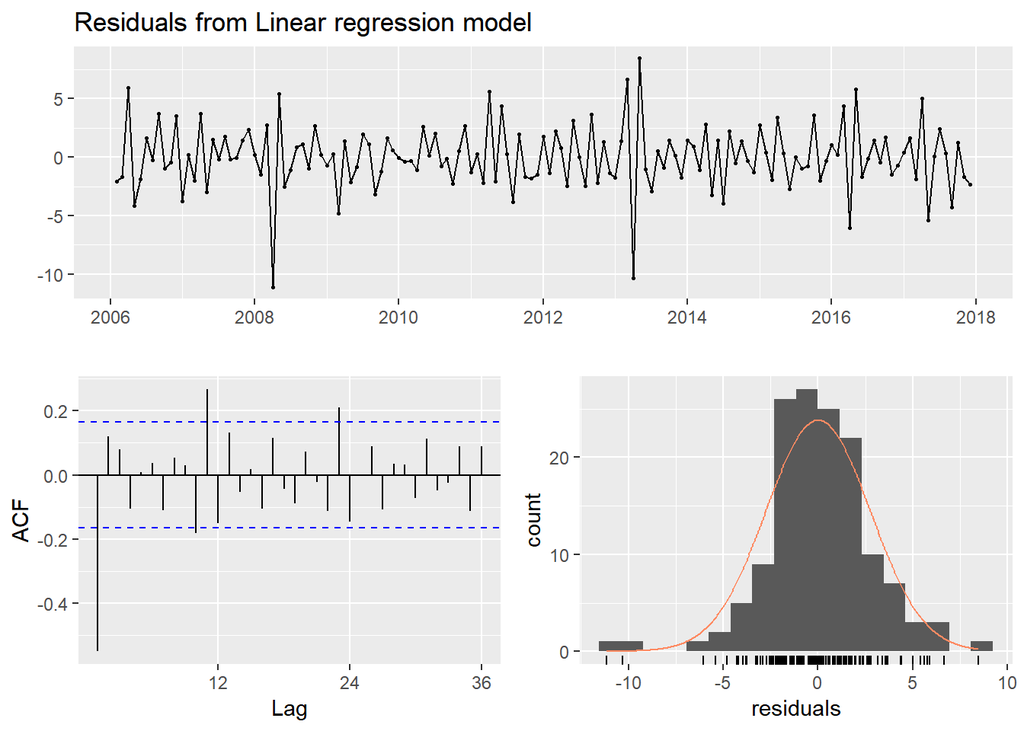

```
## Evaluación de los residuos, Regresión Lineal: 2
```

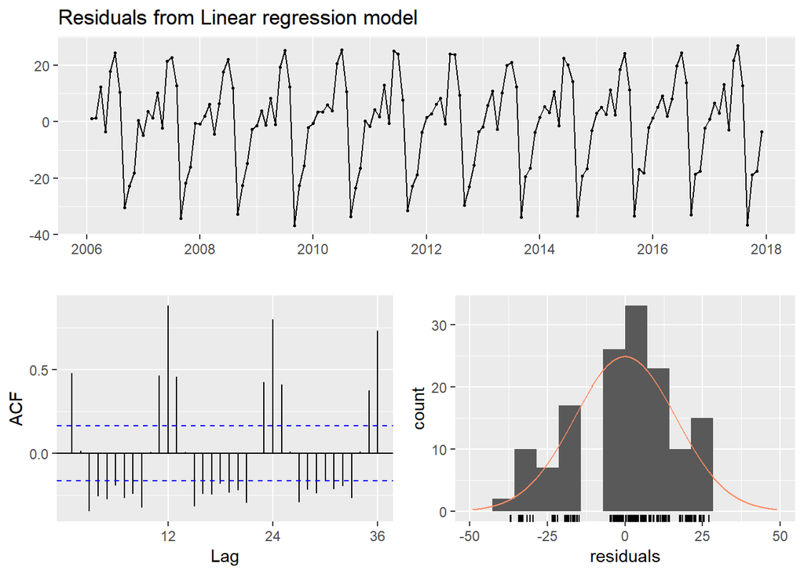

```
## Evaluación de los residuos, Regresión Lineal: 3
```

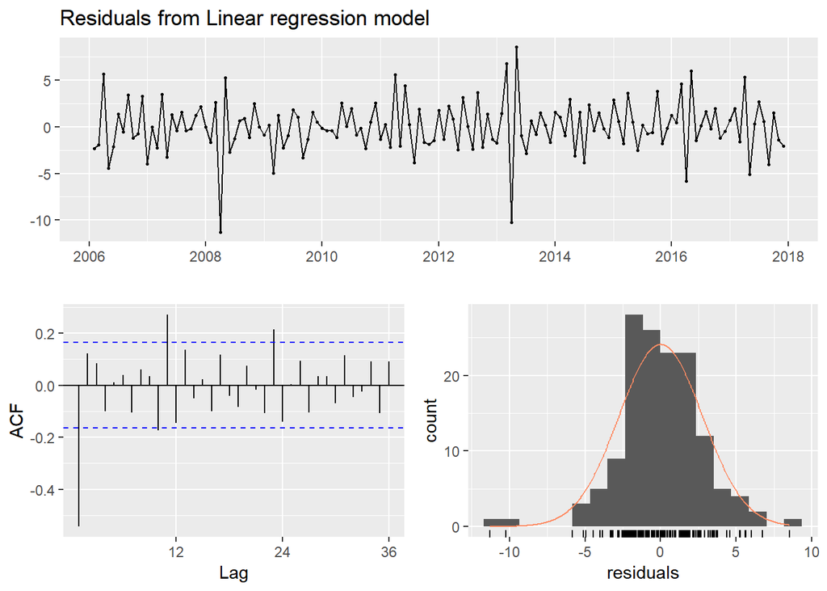

Observando las gráficas superiores se asume que los ajustes realizados por los modelos implementados no serán demasiado eficientes, ya que los residuos siempre muestran autocorrelación.

En cualquier caso, se comprueban diversos estadísticos para observar qué modelo se ajusta mejor.

```
##            tslm_1        tslm_2      tslm_3
## CV      9.1639138 272.814899896   9.0560037
## AIC   317.5829953 803.976478931 316.1224152
## AICc  320.8642453 804.149140801 318.9441207
## BIC   359.0628201 812.865012822 354.6393954
## AdjR2   0.9688054  -0.006483397   0.9689266
```

Siguiendo el criterio del AIC, se determina que es el tercer modelo ($serie = \beta_o + \beta_1Estacionalidad + \epsilon_t$) el que se ajusta de mejor manera a los datos.

Se elaboran las predicciones y se representan.

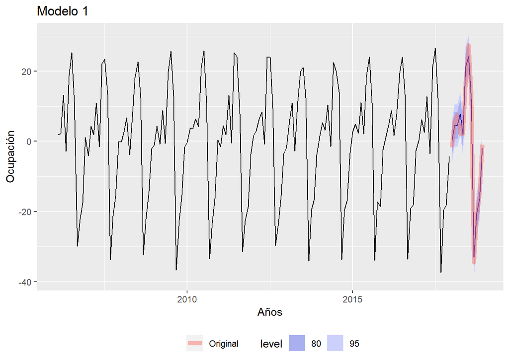

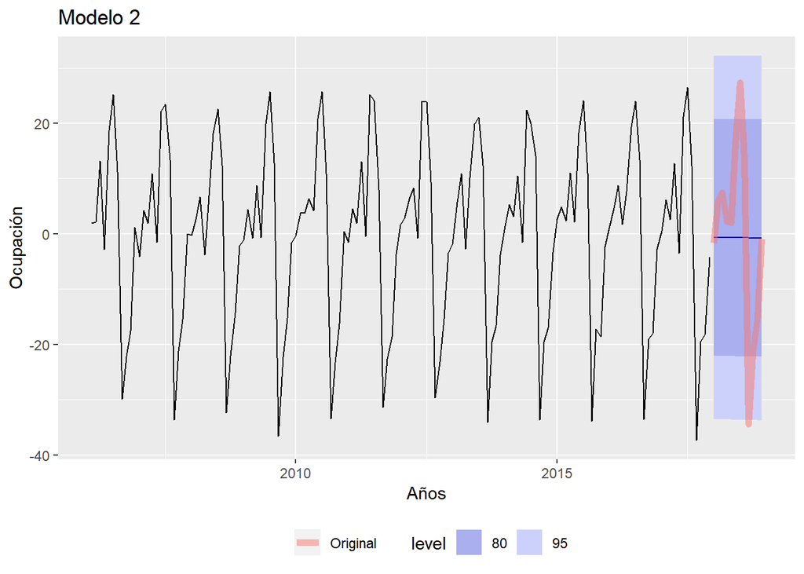

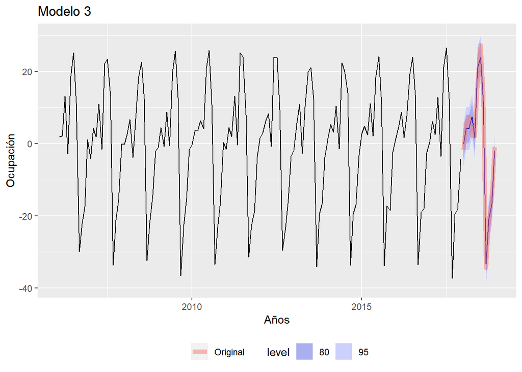

```
##            Set       Method      RMSE       MAE       ACF1
## 1 Training Set prediction_1  2.752551  2.012959 -0.5494674
## 2     Test Set prediction_1  2.673997  2.170961 -0.3273325
## 3 Training Set prediction_2 16.283097 12.749964  0.4799428
## 4     Test Set prediction_2 16.312703 12.507930  0.4795602
## 5 Training Set prediction_3  2.757747  2.023187 -0.5436351
## 6     Test Set prediction_3  2.662537  2.226452 -0.3275111
```

### Métodos de Alisado Exponencial

En este apartado se implementan diversos métodos de alisado exponencial. Estos métodos se caracterizan por ser métodos que utilizan medias ponderadas de observaciones pasadas con un decaimiento exponencial de los pesos conforme las observaciones son más antiguas.

Los métodos implementados serán:

En este caso se utiliza la serie sin transformar para observar los resultados. **Holt Damped Trend**

```r
holt_1 <- holt(train, damped=TRUE, phi = 0.9, h=12)
metric_printer(fits = List(holt_1), test = test)
```

```
##            Set Method     RMSE      MAE      ACF1
## 1 Training Set holt_1 424024.7 287323.0 0.2875530
## 2     Test Set holt_1 773701.7 481198.6 0.6113217
```

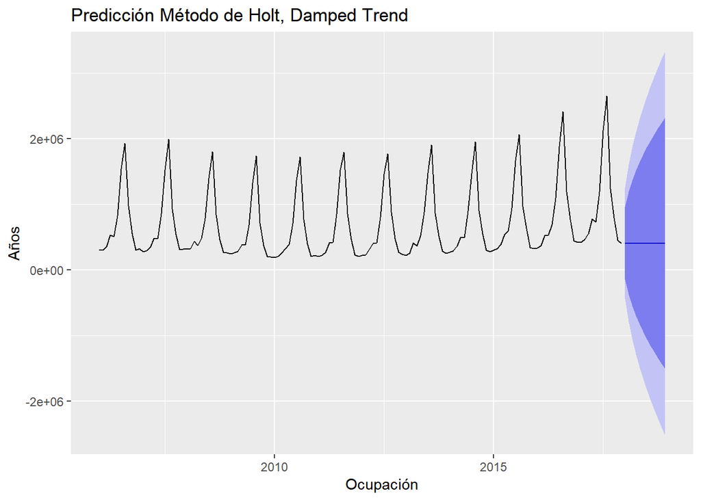

**Holt-Winters con esquema aditivo**

```r
hwadd <- hw(train, damped = TRUE, h = 12, phi = 0.9, seasonal="additive")
metric_printer(fits = List(hwadd), test = test)
```

```
##            Set Method      RMSE       MAE      ACF1
## 1 Training Set  hwadd  62759.08  45507.83 0.2964987
## 2     Test Set  hwadd 156843.00 125690.78 0.4013575
```

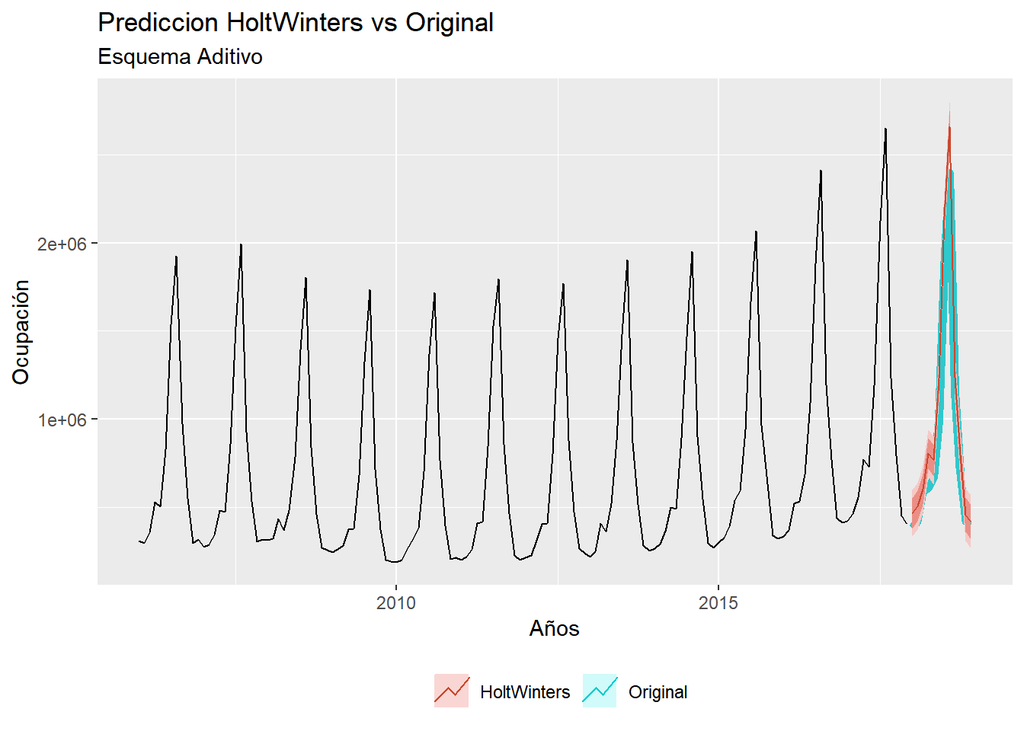

**Holt-Winters con esquema multiplicativo**

```r
hwmult <- hw(train, damped = TRUE, h = 12, phi = 0.9, seasonal="multiplicative")
metric_printer(fits = List(hwmult), test = test)
```

```
##            Set Method      RMSE      MAE      ACF1
## 1 Training Set hwmult  56672.36 42990.82 0.3707145
## 2     Test Set hwmult 128548.02 98875.10 0.5457740
```

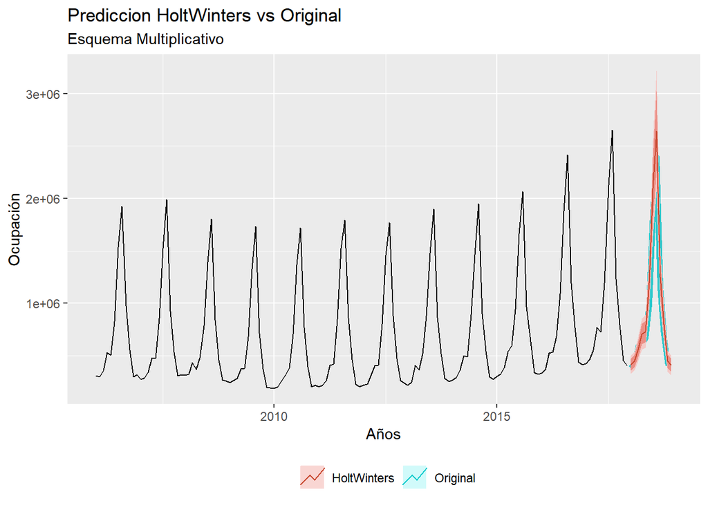

**Exponential smoothing state space model (ETS)**

```r
# MMA
ets_maa <- ets(y = train, model = "MAA", allow.multiplicative.trend = FALSE)

# MMM
ets_damped_mma <- ets(y = train, model = "MMM", damped = TRUE, phi = 0.93 ,allow.multiplicative.trend = TRUE)

# Automatic
ets_auto <- ets(y = train, model = "ZZZ", damped = TRUE, allow.multiplicative.trend = TRUE)

ets_models <- List(ets_maa, ets_damped_mma, ets_auto)
```

Comprobación a través del estadístico AIC de que modelo ETS produciría mejores resultados:

```
## AIC, ETS Model 1 -> 3857.226
## AIC, ETS Model 2 -> 3836.222
## AIC, ETS Model 3 -> 3829.422
```

Se observa que es el modelo automático el que obtiene un AIC más bajo, por lo tanto, se muestran a continuación sus características.

```
## ETS(M,Md,M)
##
## Call:
##  ets(y = train, model = "ZZZ", damped = TRUE, allow.multiplicative.trend = TRUE)
##
##   Smoothing parameters:
##     alpha = 0.5736
##     beta  = 0.004
##     gamma = 1e-04
##     phi   = 0.98
##
##   Initial states:
##     l = 715426.0015
##     b = 0.9994
##     s = 0.3945 0.4168 0.7591 1.3204 2.8246 2.2611
##            1.2736 0.7304 0.6755 0.5354 0.4165 0.3922
##
##   sigma:  0.0861
##
##      AIC     AICc      BIC
## 3829.422 3834.894 3882.879
##
## Training set error measures:
##                    ME    RMSE     MAE         MPE    MAPE      MASE
## Training set 3172.775 52662.5 37663.6 -0.07348674 6.15372 0.5959058
##                   ACF1
## Training set 0.1501959
```

Finalmente, se decide realizar la predicción utilizando el modelo automático:

```
##            Set       Method     RMSE      MAE      ACF1
## 1 Training Set prediction_1  52662.5  37663.6 0.1501959
## 2     Test Set prediction_1 265779.8 176584.3 0.6798659
```

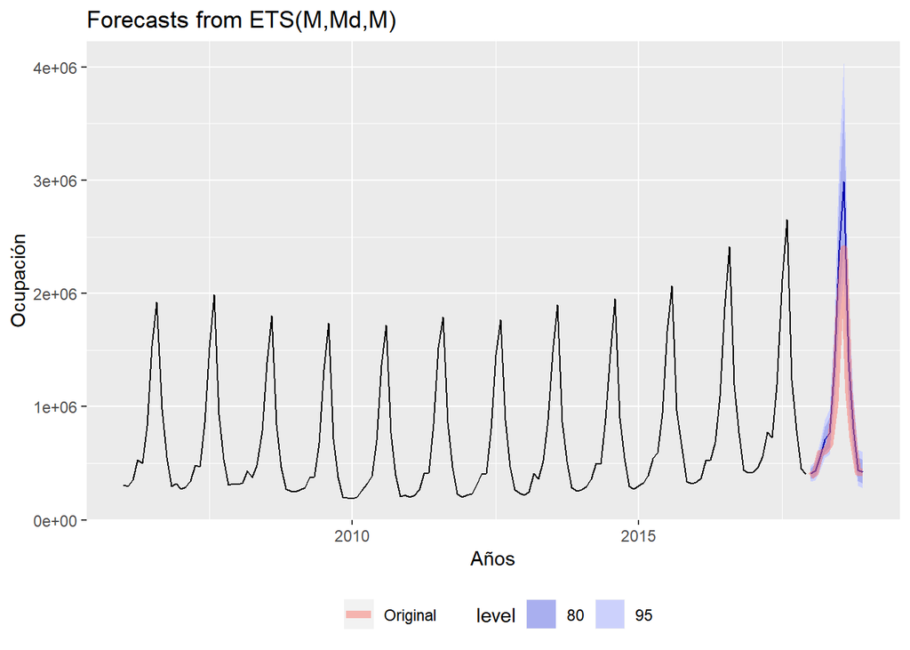

En este caso, es el Método Holt-Winters que sigue un esquema multiplicativo de la tendencia el que proporciona mejores resultados de predicción, siendo el método de holt el que produce peores resultados, situación que es obvia dada la alta estacionalidad de la serie, la cual no es capaz de capturar.

### Modelos ARIMA

En este apartado se tratará de implementar algunos modelos ARIMA (Autoregressive integrated moving average), se recuerda que estos modelos tienen como objetivo describir las asutocorrelaciones en los datos.

Como ya se comentó en anteriores apartados del ejercicio, la serie temporal analizada se caracteriza por ser no estacionaria, por lo tanto, para tratar de obtener mejores resultados con modelos ARIMA, se utilizará la serie aplicando inicialmente una transformación Box-Cox para obtener una serie con una variabilidad más estabilizada.

Se calcula el Test de Dickey–Fuller aumentado para comprobar que, efectivamente, se trata de una serie no estacionaria.

[Test de Dickey–Fuller aumentado:](https://en.wikipedia.org/wiki/Augmented_Dickey%E2%80%93Fuller_test)

```
##
##  Augmented Dickey-Fuller Test
##
## data:  series
## Dickey-Fuller = -1.7594, Lag order = 12, p-value = 0.6767
## alternative hypothesis: stationary
```

Se realizarán, en este caso, dos modelos ARIMA, el primero de ellos utilizando la función `auto.arima()` del paquete `forecast` y la función `seas()` del paquete `seasonal`, la cual llama a los procedimientos del software X-13ARIMA-SEATS.

**1. Modelo ARIMA automático**

Se lanza el modelo automático y se observan los resultados.

```r
arima_auto <- auto.arima(bc_train, seasonal = TRUE)
arima_auto
```

```
## Series: bc_train
## ARIMA(0,1,2)(0,1,1)[12]
##
## Coefficients:
##           ma1     ma2     sma1
##       -0.7236  0.2595  -0.7094
## s.e.   0.0841  0.0978   0.1003
##
## sigma^2 estimated as 6.376:  log likelihood=-310.16
## AIC=628.33   AICc=628.65   BIC=639.83
```

Se comprueban a continuación los residuos del modelo automático creado.

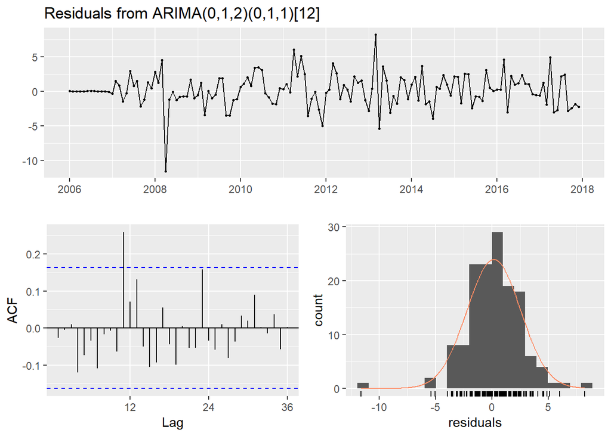

```
##
##  Ljung-Box test
##
## data:  Residuals from ARIMA(0,1,2)(0,1,1)[12]
## Q* = 31.699, df = 21, p-value = 0.06279
##
## Model df: 3.   Total lags used: 24
```

Se observa a continuación los resultados de la predicción:

```
##            Set                Method     RMSE      MAE        ACF1
## 1 Training Set arima_auto_prediction 2.380729 1.728727 -0.02708991
## 2     Test Set arima_auto_prediction 4.721110 4.223125  0.26015937
```

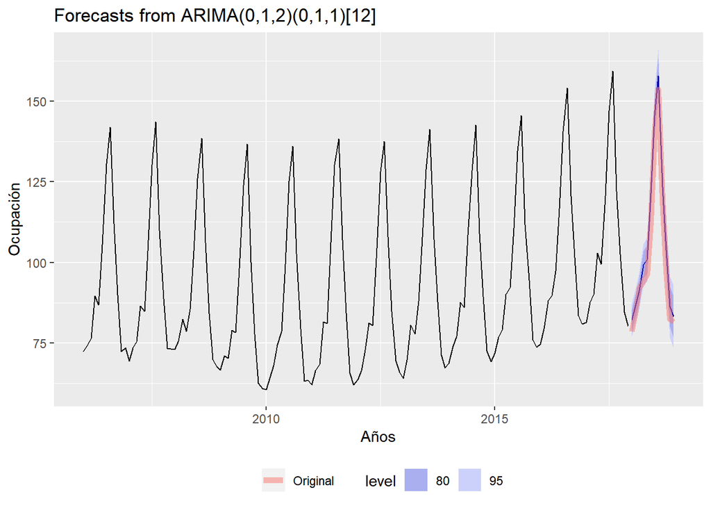

**2. Software X-13ARIMA-SEATS**

1. X-13ARIMA-SEATS con los predictores proporcionados en el ejercicio

Se decide utilizar predictores nacionales a partir de 2006. Por razones de funcionamiento se utiliza la serie original.

```r
seas_model_1 <- seas(train, xreg=reg[, c("dias.habiles", "Bisiesto")], regression.aictest = c("td"))
```

Si se observan los predictores del modelo, en este caso los residuos presentan una autocorrelación significativa.

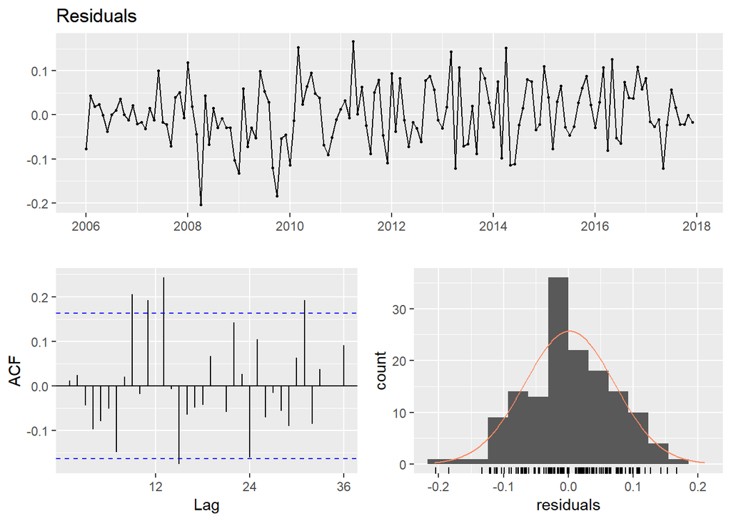

En cualquier caso, se lleva a cabo la predicción

```
##
##
## Modelo: X13-ARIMA
## --------------------------------
## MSE: 35900987045
## RMSE: 189475.6
## MAE: 141179.1
## MedianAE 100715.3
```

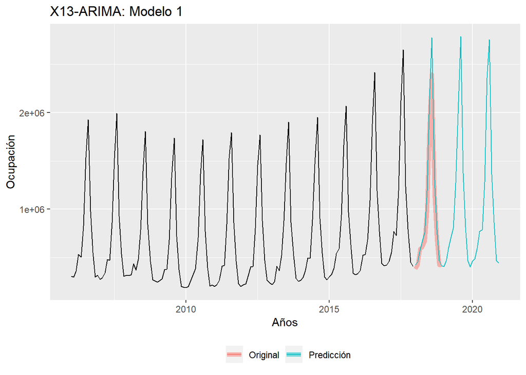

```r
autoplot(train)+
  autolayer(test, series = "Original", lwd =2, alpha = 0.5)+
  autolayer(prediction_seas_1[,1], series = "Predicción")+
  labs(title = "X13-ARIMA: Modelo 1",x = "Años", y = "Ocupación")+
  guides(colour=guide_legend(title=""))+
  theme(legend.position = "bottom")
```

2. X-13ARIMA-SEATS con predictores incluidos en el software

En este caso, se prueban varios modelos y se determina que, de los regresores incluidos en el software, los que muestran mejores resultados son *seasonal* y el *trading day*. Para este casi, sí es posible utilizar los la serie transformada con la transformación Box-Cox.

```r
# box cox tranasform is used again
seas_model_2 <- seas(bc_train, regression.variables = c("td", "seasonal"))
```

Observamos a continuación cómo los residuos del modelo no muestran autocorrelación significativa.

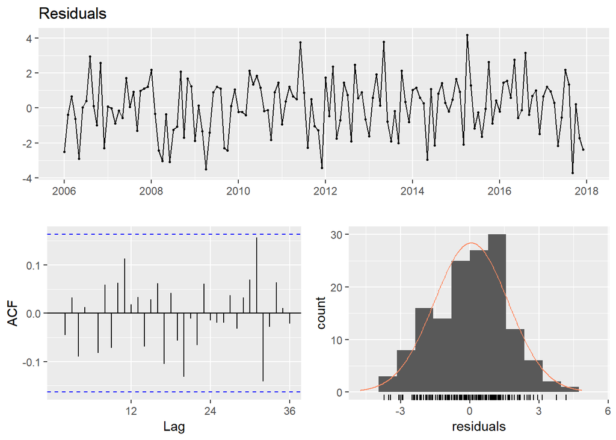

Se procede al realizar la predicción y observar sus resultados.

```
##
##
## Modelo: X13-ARIMA, Conjunto de test
## --------------------------------
## MSE: 7.528895
## RMSE: 2.743883
## MAE: 2.202079
## MedianAE 1.821451
```

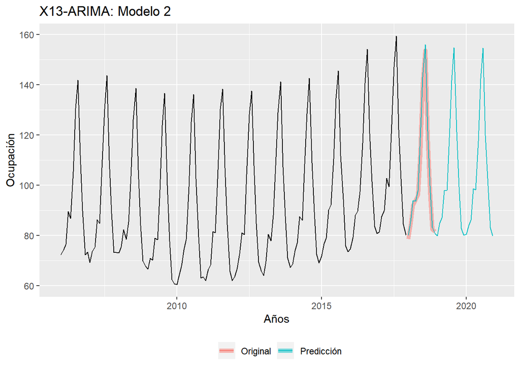

Como se puede observar, este es el modelo que **mejor** predicción muestra de todos los modelos llevados a cabo durante el ejercicio.

### Modelos con Cross-Validation

Finalmente se toman los 4 modelos que, durante el ejercicio se ha observado que tienen mejor capacidad de predicción para llevar a cabo un proceso de Time Series Cross Validation, en el cual, primeramente se tomarán los datos hasta el año 2017 (prediciendo secuencialmente, y para los diferentes horizontes, los valores de 2016 y 2017, utilizando exclusivamente los valores previos de la serie) para comprobar los errores en el conjunto de comprobación para los diversos horizontes (1-12 meses).

Para llevar a cabo este proceso se tomará la serie transformada con la transformación Box-Cox.

Los modelos que se han decidido tomar para este apartado han sido:

- Seasonal Naïve
- Holt-Winters con esquema multiplicativo
- El modelo generado con la función `auto.arima()` de la librería `forecast`
- El segundo modelo generado en el apartado de los modelos X-13ARIMA-SEATS

Se lleva a cabo el proceso y se representa el gráfico de los errores (MAE) para los diferentes horizontes en el conjunto de comprobación:

```r
# set data partition

train <- window(series_bct, start=c(2006, 1), end=c(2017, 12))
validation <- window(series_bct, start=c(2018, 1), end=c(2018, 12))

# setting connfig
k <- 132
n <- length(series_bct)
mae1 <- mae2 <- mae3 <- mae4 <- matrix(NA,n-k,12)


for(i in 0:(n-k-1)) {
  # train-test partition
  train_cv <- window(train, end=2015+11/12+i/12)
  test <- window(train, start=2015+11/12+(1+i)/12, end=2016+10/12+(1+i)/12)

  # seasonal naive
  fit1 <- snaive(train_cv, h = 12)
  fcast1 <- forecast(fit1,h = 12)

  # Holt Winters
  fit2 <- hw(train_cv, damped = TRUE, h = 12, phi = 0.9, seasonal="multiplicative")
  fcast2 <- forecast(fit2,h=12)

  # Auto.Arima
  fit3 <- auto.arima(train_cv, seasonal = TRUE)
  fcast3 <- forecast(fit3,h=12)

  # X13-ARIMA Model 2
  fit4 <- seas(train_cv, regression.variables = c("td", "seasonal"))
  fcast4 <- seasonal::series(fit4, "forecast.forecasts")
  fcast4 <- window(fcast4[,1], end = end(test))


  mae1[i+1,] <- c(abs(fcast1$mean-test),rep(NA,12-length(test)))
  mae2[i+1,] <- c(abs(fcast2$mean-test),rep(NA,12-length(test)))
  mae3[i+1,] <- c(abs(fcast3$mean-test),rep(NA,12-length(test)))
  mae4[i+1,] <- c(abs(fcast4-test),rep(NA,12-length(test)))
}
```

[output not shown]

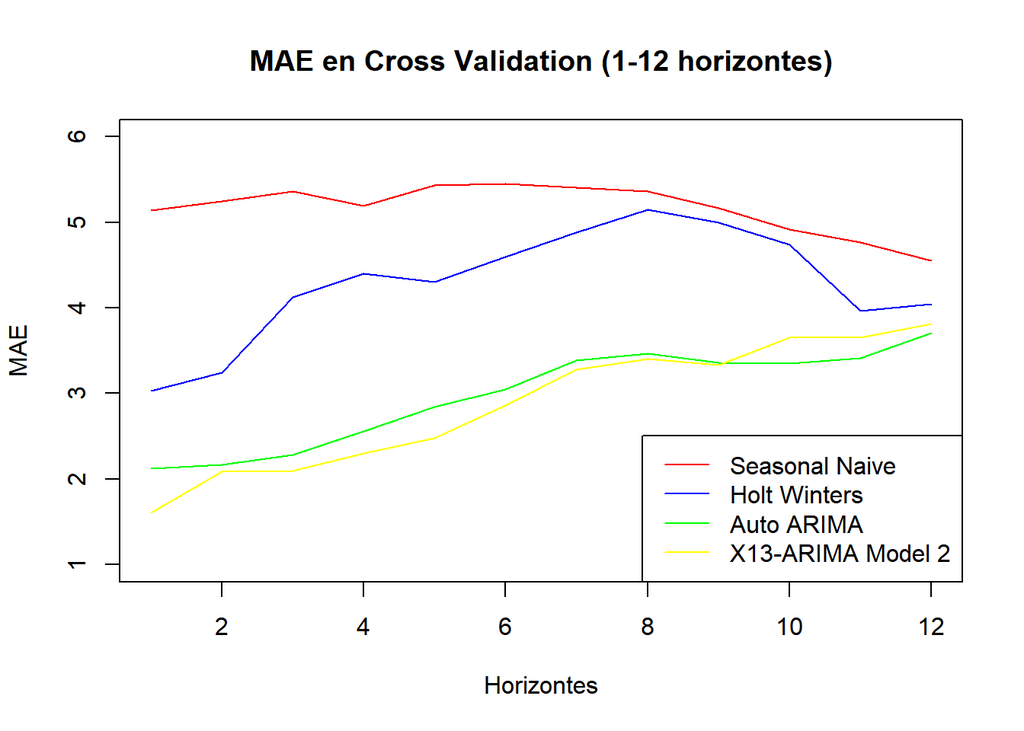

```r
plot(1:12, apply(mae1, 2, mean, na.rm=T), type="l", col="red", xlab="Horizontes",ylab="MAE", main = "MAE en Cross Validation (1-12 horizontes)", ylim = c(1, 6))
lines(1:12, apply(mae2, 2, mean, na.rm=T), type="l", col="blue", ylim = c(1, 6))
lines(1:12, apply(mae3, 2, mean, na.rm=T), type="l", col="green", ylim = c(1, 6))
lines(1:12, apply(mae4, 2, mean, na.rm=T), type="l", col="yellow", ylim = c(1, 6))
legend("bottomright", legend=c("Seasonal Naive","Holt Winters","Auto ARIMA", "X13-ARIMA Model 2"), col=c("red", "blue", "green", "yellow"), lty=1)
```

Como se puede observar, el segundo modelo X13-ARIMA es el que, durante mas horizontes, es capaz de mantener los errores más bajos, sin embargo, a partir del horizonte de los 9 meses aproximadamente, es significativo observar como el modelo generado con el procedimiento de ARIMA automático de la librería `forecast`, en promedio,consigue mejores resultados.

```r
# predictions
auto_arima_final <- fit3 %>% forecast(h = 13)
auto_arima_final <- auto_arima_final$mean[2:13]


fcast4 <- seasonal::series(fit4, "forecast.forecasts")
```

```
## specs have been added to the model: forecast
```

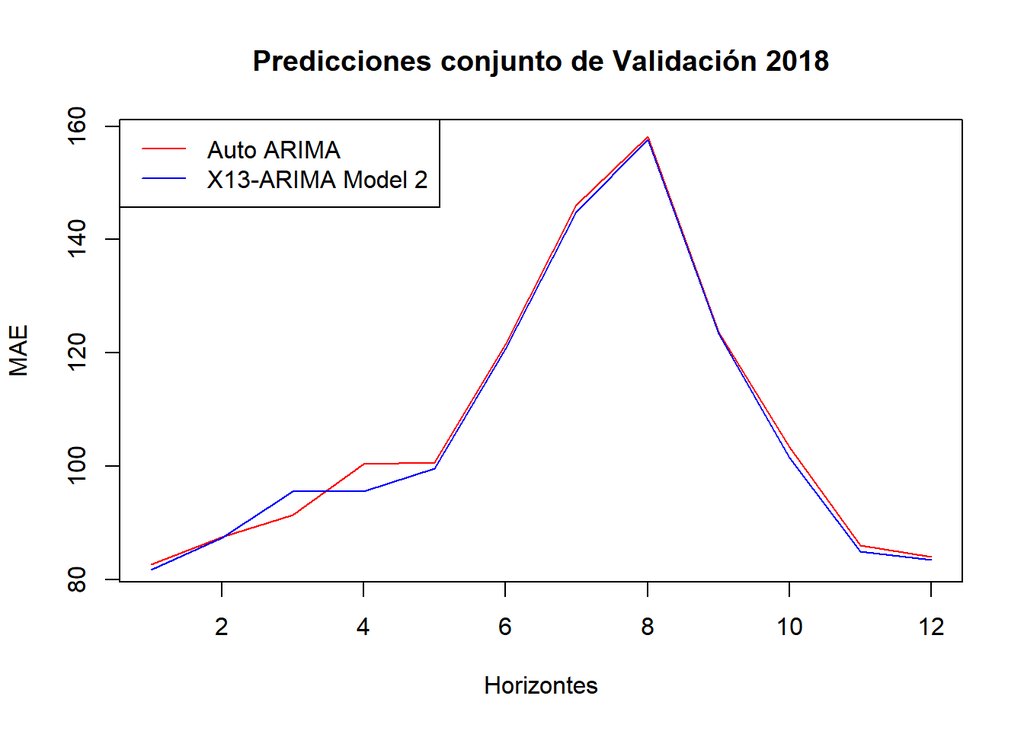

```r
fcast4 <- window(fcast4[,1], end = c(2018, 12)) %>% as.vector()
fcast4 <- fcast4[2:13]

# mae for different horizons
autoarima_mae <- abs(setdiff(auto_arima_final, validation %>% as.vector()))
x13_mae <- abs(setdiff(fcast4, validation %>% as.vector()))

plot(1:12, autoarima_mae, type = "l", col = "red", main = "Predicciones conjunto de Validación 2018", xlab = "Horizontes", ylab = "MAE")
lines(1:12, x13_mae, type = "l", col = "blue")
legend("topleft", legend=c("Auto ARIMA", "X13-ARIMA Model 2"), col=c("red", "blue"), lty=1)
```